# CEE 218X Assignment 1

Brooke Tran

September 20, 2020

```r
library(tidyverse)
library(plotly)
library(sf)
library(tigris)
library(leaflet)
library(censusapi)
```

```r
# File where data files are stored
data_directory = "data/"
```

### Import PGE data

#### Separate electric and gas to do conversions to kBTU

```r
# Loop through electricity data

years <- 2017:2019
quarters <- 1:4
type <- "Electric"
elec_data <- NULL

for(year in years) {
  for(quarter in quarters) {

    filename <-
      paste0(
        data_directory,
        "PGE_",
        year,
        "_Q",
        quarter,
        "_",
        type,
        "UsageByZip.csv"
      )

    # print(filename)
    temp <- read_csv(filename)
    elec_data <- rbind(elec_data,temp)
  }
}

# Add 2020 data (since can't loop through all 4 quarters)
year = 2020
quarters <- 1:2
type <- "Electric"

for(quarter in quarters) {
  filename <-
    paste0(
      data_directory,
      "PGE_",
      year,
      "_Q",
      quarter,
      "_",
      type,
      "UsageByZip.csv"
    )
  # print(filename)
  temp <- read_csv(filename)
  elec_data <- rbind(elec_data,temp)
}
```

```r
# Loop through gas data

years <- 2017:2019
quarters <- 1:4
type <- "Gas"
gas_data <- NULL

for(year in years) {
  for(quarter in quarters) {

    filename <-
      paste0(
        data_directory,
        "PGE_",
        year,
        "_Q",
        quarter,
        "_",
        type,
        "UsageByZip.csv"
      )

    # print(filename)
    temp <- read_csv(filename)
    gas_data <- rbind(gas_data,temp)
  }
}

# Add 2020 data (can't loop through all 4 quarters)
year = 2020
quarters <- 1:2
type <- "Gas"

for(quarter in quarters) {
  filename <-
    paste0(
      data_directory,
      "PGE_",
      year,
      "_Q",
      quarter,
      "_",
      type,
      "UsageByZip.csv"
    )
  # print(filename)
  temp <- read_csv(filename)
  gas_data <- rbind(gas_data,temp)
}
```

### Convert to kBTUs

#### 1 kWhs = 3412 BTUs = 3.412 kBTUs

#### 1 therm = 99976 BTUs = 99.976 kBTUs

```r
elec_data = elec_data %>%
  mutate(TOTALKBTU = TOTALKWH * 3.412)

gas_data = gas_data %>%
  mutate(TOTALKBTU = TOTALTHM * 99.976)
```

```r
# Remove kWh and therm columns, combine into single table
elec_data = elec_data %>%
  select(-c(COMBINED, TOTALKWH, AVERAGEKWH))

gas_data = gas_data %>%
  select(-c(COMBINED, TOTALTHM, AVERAGETHM))

total_data = rbind(elec_data, gas_data)
```

### Subset ZIP codes in Bay Area

```r
# Import .csv of Bay Area ZIP codes
bay_zips <- read_csv("https://data.sfgov.org/api/views/f9wk-m4qb/rows.csv?accessType=DOWNLOAD")

bay_zips = select(bay_zips, ZIP)

# Left join Bay Area ZIP codes and total data
bay_zip_data = left_join(bay_zips, total_data, by = c("ZIP" = "ZIPCODE"))
```

```r
# Aggregate KBTU data by month, year, and customer class

bay_data =
  bay_zip_data %>%
  group_by(MONTH, YEAR, CUSTOMERCLASS) %>%
  summarize(
    TOTALCUSTOMERS =
      sum(
        TOTALCUSTOMERS,
        na.rm = T
      ),
    TOTALKBTU =
      sum(
        TOTALKBTU,
        na.rm = T
      )
  )
```

```r
# Create date variable
bay_data =
  bay_data %>%
  mutate(
    DATE = as.Date(paste(MONTH, "01", YEAR, sep="-"),
                   format = "%m-%d-%Y")
  )
```

### Plot data

```r
# Theme for data visualizations
th = theme_bw() + theme(
  # Title
  legend.title = element_blank(),
  plot.title = element_text(size = 18, hjust = .5, face = "bold"),
  # Legend
  legend.text = element_text(size = 13),
  legend.position = "bottom",
  # Caption
  plot.caption = element_text(size = 9, hjust = .5,face = "italic"),
  # X-axis
  axis.ticks.x=element_blank(),
  # Y-axis
  axis.ticks.y=element_blank(),
  # Background
  panel.grid.major = element_blank(),
  panel.grid.minor = element_blank(),
  panel.background = element_blank(),
  axis.line = element_line(colour = "black"),
  panel.border = element_blank())
```

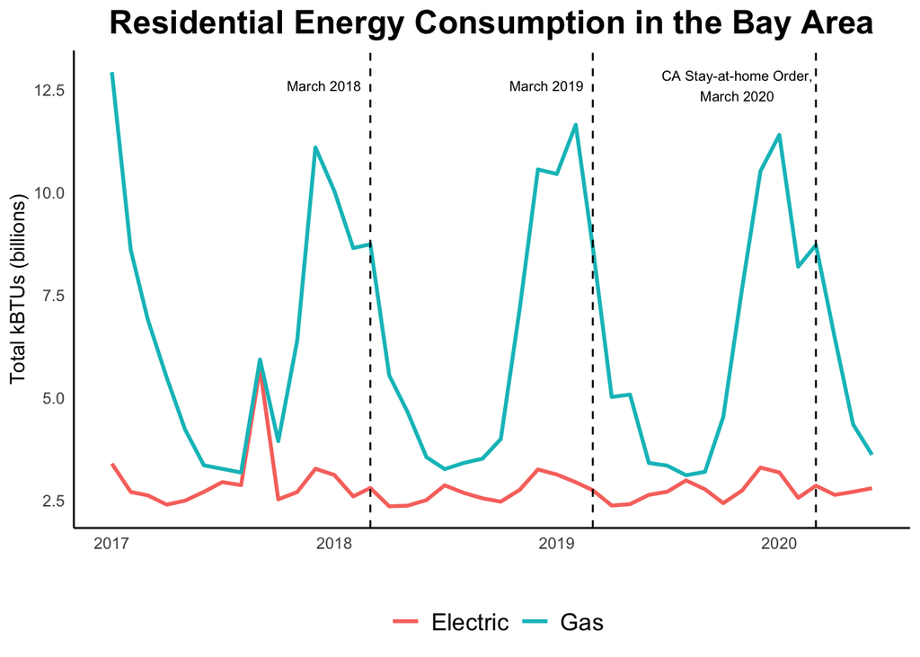

```r
# Residential data
res_plot =
  ggplot(subset(bay_data,
                CUSTOMERCLASS == "Gas- Residential" |
                  CUSTOMERCLASS == "Elec- Residential"),
         aes(x=DATE,
             y = TOTALKBTU/1e9)) +
  geom_line(aes(color = CUSTOMERCLASS), size = 1) +
  ggtitle("Residential Energy Consumption in the Bay Area") +
  labs(x = "", y = "Total kBTUs (billions)") +
  scale_color_hue(labels = c("Electric", "Gas")) +
  geom_vline(xintercept = as.numeric(as.Date("2020-03-01")), linetype=2) +
  geom_vline(xintercept = as.numeric(as.Date("2019-03-01")), linetype=2) +
  geom_vline(xintercept = as.numeric(as.Date("2018-03-01")), linetype=2) +
  annotate(geom="text", x=as.Date("2019-10-24"), y=12.6, label="CA Stay-at-home Order,\nMarch 2020", size = 2.7) +
  annotate(geom="text", x=as.Date("2018-12-15"), y=12.6, label="March 2019", size = 2.7) +
  annotate(geom="text", x=as.Date("2017-12-15"), y=12.6, label="March 2018", size = 2.7) +
  th

res_plot
```

Across the 3 years of data, there appears to be a consistent pattern of residential energy consumption that aligns with seasonal patterns. The state of California issued a stay-at-home order in March 2020, restricting people from leaving their homes. It is around this time we would expect to see the greatest shifts in residential energy consumption, as people are spending more time at home rather than at work or school. To determine whether there were any observable changes that may be attributable to the COVID-19 pandemic, I compared energy consumption during this time across previous years to see if there are any noticeable differences. It would not be sufficient to only look at consumption before and after the stay-at-home order, since there are fluctuations that occur as the weather changes across months. Therefore, by comparing consumption to previous years, we are accounting for seasonality in the data.

Using this method, it is not immediately clear that the COVID-19 pandemic dramatically changed residential energy consumption. Around the time of March, gas and electricity consumption is steadily decreasing. While we do observe a sudden decrease in energy after March 2020, we also see this pattern occur in March 2018 when there was no stay-at-home order in place. In fact, the trends in 2018 overall are nearly identical to the consumption patterns in 2020. Therefore, I would conclude that despite the many life-altering changes attributed to COVID-19, residential energy consumption has not changed significantly.

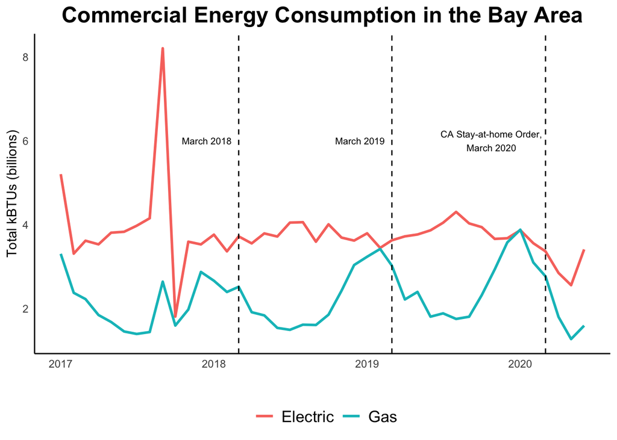

```r
# Commercial data
com_plot =
  ggplot(subset(bay_data,
                CUSTOMERCLASS == "Gas- Commercial" |
                  CUSTOMERCLASS == "Elec- Commercial"),
         aes(x=DATE,
             y = TOTALKBTU/1e9)) +
  geom_line(aes(color = CUSTOMERCLASS), size = 1) +
  ggtitle("Commercial Energy Consumption in the Bay Area") +
  labs(x = "", y = "Total kBTUs (billions)") +
  scale_color_hue(labels = c("Electric", "Gas")) +
  geom_vline(xintercept = as.numeric(as.Date("2020-03-01")), linetype=2) +
  geom_vline(xintercept = as.numeric(as.Date("2019-03-01")), linetype=2) +
  geom_vline(xintercept = as.numeric(as.Date("2018-03-01")), linetype=2) +
  annotate(geom="text", x=as.Date("2019-10-24"), y=6, label="CA Stay-at-home Order,\nMarch 2020", size = 2.7) +
  annotate(geom="text", x=as.Date("2018-12-15"), y=6, label="March 2019", size = 2.7) +
  annotate(geom="text", x=as.Date("2017-12-15"), y=6, label="March 2018", size = 2.7) +
  th

com_plot
```

Commercial energy consumption in the Bay Area follows significantly different patterns compared to residential consumption: electricity consumption remains relatively stable across seasons, while gas consumption fluctuates based on seasonal patterns. Therefore, if there were significant changes in consumption due to the pandemic, we would expect both gas and electricity consumption after March 2020 to deviate from typical patterns for this point in previous years.

What we observe is that electricity consumption appears to decline to levels not seen since before 2018, and this decline occurs over a longer stretch of time than typical fluctuations. Gas consumption after March 2020 also deviates from previous years. While there is typically a decline during this time of the year, the decrease was more dramatic in 2020, reaching the lowest level of total kBTUs in the data across the 4 years observed. These findings point to significant changes in commercial energy consumption due to the COVID-19 pandemic.

### Map of neighborhoods with greatest change in energy consumption.

To visualize neighborhoods that experienced the greatest change in electricity consumption due to the COVID-19 pandemic, I followed a similar methodology to the analyze previous figures. The goal was to compare the same period of time across several years, to account for seasonal changes across months and determine whether 2020 deviates from these typical patterns.

My approach to doing this was the following:

- Subset the months of April to June from the data for analysis, as these months of the pandemic were the captured in the 2020 data.
- Take the average consumption of this “pandemic period” across 2017-2019 to establish a point of reference for what typical consumption would be during normal times.
- Using the consumption rates during normal times (2017-2019) and the rates during the pandemic (2020), compute the percent change for each ZIP code region (initially, I tried to just look at the net difference, but this did not account for the population/size differences across areas).
- Map the percent changes for each ZIP code to see which neighborhoods saw the greatest change in electricity consumption.

```r
# Filter month observations from April to June
# Filter residential and commercial electricity consumption
pandemic_data = bay_zip_data %>% filter(MONTH %in% c(4:6),
                                        CUSTOMERCLASS %in%
                                          c("Elec- Commercial",
                                            "Elec- Residential"))

# Remove total customers column
pandemic_data = pandemic_data %>% select(-TOTALCUSTOMERS)
```

```r
# Aggregate 3 month period into single total consumption during that time per year
pandemic_data =
  pandemic_data %>%
  group_by(ZIP, YEAR) %>%
  summarize(
    TOTALKBTU =
      sum(
        TOTALKBTU,
        na.rm = T
      )
  )
```

```r
# Get average for 2017-2019 to compare to 2020 consumption

# Split data into pre- and post-pandemic, then recombine
prepandemic_data = pandemic_data %>% filter(YEAR %in% c(2017:2019))
postpandemic_data = pandemic_data %>% filter(YEAR == 2020)
```

```r
# Aggregate pre-pandemic data by ZIP
prepandemic_data =
  prepandemic_data %>%
  group_by(ZIP) %>%
  summarize(
    AVG_TOTAL_KBTU =
      mean(
        TOTALKBTU,
        na.rm = T
      )
  )
```

```r
# Rename/manipulate columns to combine (width-wise)
# Pre-pandemic data processing
prepandemic_data =
  prepandemic_data %>%
  rename(PRE_AVG_TOTAL_KBTU = AVG_TOTAL_KBTU)

# Post-pandemic data processing
postpandemic_data =
  postpandemic_data %>%
  rename(POST_AVG_TOTAL_KBTU = TOTALKBTU)

postpandemic_data = postpandemic_data %>% select(-YEAR)

prepandemic_data = as.data.frame(prepandemic_data)
postpandemic_data = as.data.frame(postpandemic_data)

# Clean data
map_data = left_join(prepandemic_data, postpandemic_data, by = "ZIP")
```

```r
# COMPUTE PERCENT CHANGE IN ENERGY CONSUMPTION
map_data = map_data %>%
  mutate(PCT_CHANGE_KBTU = (POST_AVG_TOTAL_KBTU - PRE_AVG_TOTAL_KBTU)/PRE_AVG_TOTAL_KBTU * 100)
```

### Setting up mapping data

```r
# Setting up geometry data for mapping:

usa_zips <-
  zctas(cb = T, progress_bar = F)

ca_counties <- counties("CA", cb = T, progress_bar = F)

bay_county_names <-
  c(
    "Alameda",
    "Contra Costa",
    "Marin",
    "Napa",
    "San Francisco",
    "San Mateo",
    "Santa Clara",
    "Solano",
    "Sonoma"
  )

bay_counties <-
  ca_counties %>%
  filter(NAME %in% bay_county_names)

bay_zips <-
  usa_zips %>%
  st_centroid() %>%
  .[bay_counties, ] %>%
  st_set_geometry(NULL) %>%
  left_join(usa_zips %>% select(GEOID10)) %>%
  st_as_sf()
```

```r
map_geodata <-
  map_data %>%
  mutate(ZIP = ZIP %>% as.character()) %>%
  left_join(
    bay_zips %>% select(GEOID10),
    by = c("ZIP" = "GEOID10")
  ) %>%
  st_as_sf() %>%
  st_transform(4326)
```

```r
# Remove NA values from map
map_geodata <- na.omit(map_geodata)
```

### Map of % change in energy consumption

```r
res_pal <- colorNumeric(
  palette = "GnBu",
  domain =
    map_geodata$PCT_CHANGE_KBTU
)

leaflet() %>%
  addTiles() %>%
  addPolygons(
    data = map_geodata,
    fillColor = ~res_pal(PCT_CHANGE_KBTU),
    color = "light gray",
    opacity = 0.5,
    fillOpacity = 1,
    weight = 1,
    label = ~paste0(
      round(PCT_CHANGE_KBTU),
      " % change in kBTU total in ",
      ZIP
    ),
    highlightOptions = highlightOptions(
      weight = 2,
      opacity = 1
    )
  ) %>%
  addLegend(
    data = map_geodata,
    pal = res_pal,
    values = ~PCT_CHANGE_KBTU,
    title = "% Change kBTU"
  ) %>%
  addProviderTiles(providers$CartoDB.Positron)
```

[interactive chart not shown]

Regions within the Bay Area experienced both increased and decreased residential and commercial electricity consumption during the pandemic. Based on the map, there doesn’t appear to be a clear pattern or spatial trend, the distribution looks a bit random. In future analysis, I’d be interested in exploring why certain regions have such dramatic changes.

For positive increases, ZIP codes 94545 and 94938 both saw over a 250% increase in consumption. The 3 ZIP codes with the next highest positive % increases are 94108 (115%), 94606 (96%), and 94110 (81%).

### Top 5 neighborhoods with greatest % increase in electricity consumption

```r
map_geodata_inc = map_geodata %>%
  arrange(desc(PCT_CHANGE_KBTU)) %>%
  st_set_geometry(NULL)

map_geodata_inc[1:5,c(1,4)]
```

|  | ZIP | PCT_CHANGE_KBTU |
| --- | --- | --- |
| 1 | 94938 | 253.07040 |
| 2 | 94545 | 251.32793 |
| 3 | 94108 | 114.97396 |
| 4 | 94606 | 96.49089 |
| 5 | 94110 | 80.55512 |

Some regions in the Bay Area saw negative % changes in energy consumption. The top 5 ZIP codes with the greatest decreases are 94104 (-99%), 94111 (-96%), 94544 (-79%), 94124 (-73%), and 94403 (-70%).

### Top 5 neighborhoods with greatest % decrease in electricity consumption

```r
map_geodata_dec = map_geodata %>%
  arrange(PCT_CHANGE_KBTU) %>%
  st_set_geometry(NULL)

map_geodata_dec[1:5,c(1,4)]
```

|  | ZIP | PCT_CHANGE_KBTU |
| --- | --- | --- |
| 1 | 94104 | -99.00680 |
| 2 | 94111 | -96.49402 |
| 3 | 94544 | -78.68200 |
| 4 | 94124 | -72.64718 |
| 5 | 94403 | -70.25472 |